# Project: Tmdb movies Data Analysis

## Questions

- Which genres are most popular from year to year?
- What kinds of properties are associated with movies that have high revenues?

```python
# Import packages and libraries that used in the project:
import pandas as pd
import numpy as np
import matplotlib.pyplot as plt
import seaborn as sns
%matplotlib inline
```

## Data Wrangling

### General Properties

```python
# Load your data and print out a few lines.
df=pd.read_csv('tmdb-movies.csv')
df.head(3)
```

|  | id | imdb_id | popularity | budget | revenue | original_title | cast | homepage | director | tagline | ... | overview | runtime | genres | production_companies | release_date | vote_count | vote_average | release_year | budget_adj | revenue_adj |
| --- | --- | --- | --- | --- | --- | --- | --- | --- | --- | --- | --- | --- | --- | --- | --- | --- | --- | --- | --- | --- | --- |
| 0 | 135397 | tt0369610 | 32.985763 | 150000000 | 1513528810 | Jurassic World | Chris Pratt\|Bryce Dallas Howard\|Irrfan Khan\|Vi... | http://www.jurassicworld.com/ | Colin Trevorrow | The park is open. | ... | Twenty-two years after the events of Jurassic ... | 124 | Action\|Adventure\|Science Fiction\|Thriller | Universal Studios\|Amblin Entertainment\|Legenda... | 6/9/15 | 5562 | 6.5 | 2015 | 1.379999e+08 | 1.392446e+09 |
| 1 | 76341 | tt1392190 | 28.419936 | 150000000 | 378436354 | Mad Max: Fury Road | Tom Hardy\|Charlize Theron\|Hugh Keays-Byrne\|Nic... | http://www.madmaxmovie.com/ | George Miller | What a Lovely Day. | ... | An apocalyptic story set in the furthest reach... | 120 | Action\|Adventure\|Science Fiction\|Thriller | Village Roadshow Pictures\|Kennedy Miller Produ... | 5/13/15 | 6185 | 7.1 | 2015 | 1.379999e+08 | 3.481613e+08 |
| 2 | 262500 | tt2908446 | 13.112507 | 110000000 | 295238201 | Insurgent | Shailene Woodley\|Theo James\|Kate Winslet\|Ansel... | http://www.thedivergentseries.movie/#insurgent | Robert Schwentke | One Choice Can Destroy You | ... | Beatrice Prior must confront her inner demons ... | 119 | Adventure\|Science Fiction\|Thriller | Summit Entertainment\|Mandeville Films\|Red Wago... | 3/18/15 | 2480 | 6.3 | 2015 | 1.012000e+08 | 2.716190e+08 |

3 rows × 21 columns

- In the cast and genres we have mupliple item seperated by "|", for budget_adj and revenue_adj columns we cannot see the exact number.

```python
# Check the dataset shape
df.shape
```

```
(10866, 21)
```

- There are 10866 records and 21 columns(features) in the original dataset.

```python
#Check the data structure
df.info()
```

```
<class 'pandas.core.frame.DataFrame'>
RangeIndex: 10866 entries, 0 to 10865
Data columns (total 21 columns):
 #   Column                Non-Null Count  Dtype
---  ------                --------------  -----
 0   id                    10866 non-null  int64
 1   imdb_id               10856 non-null  object
 2   popularity            10866 non-null  float64
 3   budget                10866 non-null  int64
 4   revenue               10866 non-null  int64
 5   original_title        10866 non-null  object
 6   cast                  10790 non-null  object
 7   homepage              2936 non-null   object
 8   director              10822 non-null  object
 9   tagline               8042 non-null   object
 10  keywords              9373 non-null   object
 11  overview              10862 non-null  object
 12  runtime               10866 non-null  int64
 13  genres                10843 non-null  object
 14  production_companies  9836 non-null   object
 15  release_date          10866 non-null  object
 16  vote_count            10866 non-null  int64
 17  vote_average          10866 non-null  float64
 18  release_year          10866 non-null  int64
 19  budget_adj            10866 non-null  float64
 20  revenue_adj           10866 non-null  float64
dtypes: float64(4), int64(6), object(11)
memory usage: 1.7+ MB
```

- We have missing value in homepage, tagline, keywords, genres, production_comapanies, overview and imdbid.
- I think some columns (id, imdb_id, homepage, original_title, tagline, keywords, overview) aren't relevant to our analysis.
- Data type for release_date is not correct. should be datetime.
- Release_year and release_date refer to the same thing.

```python
# drop columns from df dataset since they aren't relevant to our analysis.
df.drop(['id','imdb_id','homepage','original_title','cast','tagline','keywords','overview','release_date'], axis=1, inplace=True)
```

```python
df.head(1)
```

|  | popularity | budget | revenue | director | runtime | genres | production_companies | vote_count | vote_average | release_year | budget_adj | revenue_adj |
| --- | --- | --- | --- | --- | --- | --- | --- | --- | --- | --- | --- | --- |
| 0 | 32.985763 | 150000000 | 1513528810 | Colin Trevorrow | 124 | Action\|Adventure\|Science Fiction\|Thriller | Universal Studios\|Amblin Entertainment\|Legenda... | 5562 | 6.5 | 2015 | 1.379999e+08 | 1.392446e+09 |

```python
# Check the statistic information for numerical variables.
df.describe()
```

|  | popularity | budget | revenue | runtime | vote_count | vote_average | release_year | budget_adj | revenue_adj |
| --- | --- | --- | --- | --- | --- | --- | --- | --- | --- |
| count | 10866.000000 | 1.086600e+04 | 1.086600e+04 | 10866.000000 | 10866.000000 | 10866.000000 | 10866.000000 | 1.086600e+04 | 1.086600e+04 |
| mean | 0.646441 | 1.462570e+07 | 3.982332e+07 | 102.070863 | 217.389748 | 5.974922 | 2001.322658 | 1.755104e+07 | 5.136436e+07 |
| std | 1.000185 | 3.091321e+07 | 1.170035e+08 | 31.381405 | 575.619058 | 0.935142 | 12.812941 | 3.430616e+07 | 1.446325e+08 |
| min | 0.000065 | 0.000000e+00 | 0.000000e+00 | 0.000000 | 10.000000 | 1.500000 | 1960.000000 | 0.000000e+00 | 0.000000e+00 |
| 25% | 0.207583 | 0.000000e+00 | 0.000000e+00 | 90.000000 | 17.000000 | 5.400000 | 1995.000000 | 0.000000e+00 | 0.000000e+00 |
| 50% | 0.383856 | 0.000000e+00 | 0.000000e+00 | 99.000000 | 38.000000 | 6.000000 | 2006.000000 | 0.000000e+00 | 0.000000e+00 |
| 75% | 0.713817 | 1.500000e+07 | 2.400000e+07 | 111.000000 | 145.750000 | 6.600000 | 2011.000000 | 2.085325e+07 | 3.369710e+07 |
| max | 32.985763 | 4.250000e+08 | 2.781506e+09 | 900.000000 | 9767.000000 | 9.200000 | 2015.000000 | 4.250000e+08 | 2.827124e+09 |

- We can see the min value in budget and revenue columns are 0 which doesn't make sense so we need to deal with this data quality issue.

```python
# Check missing value
df.isnull().sum()
```

```
popularity                 0
budget                     0
revenue                    0
director                  44
runtime                    0
genres                    23
production_companies    1030
vote_count                 0
vote_average               0
release_year               0
budget_adj                 0
revenue_adj                0
dtype: int64
```

- Basically, 3 columns have missing value, we can remove it in the data cleaning process.

```python
# Check duplicated value
df.duplicated().sum()
```

```
1
```

- In this case, we see there is one duplicated record so we remove it.

### Data Cleaning

```python
# drop duplicated records
df.drop_duplicates(inplace=True)
```

```python
#Check duplicated
df.duplicated().sum()
```

```
0
```

```python
# Deal with missing valye
#1. Remove missing value in genre
df.dropna(subset=['genres','director','production_companies'],inplace=True)
```

```python
# Check if any of columns have missing value.
df.isnull().any()
```

```
popularity              False
budget                  False
revenue                 False
director                False
runtime                 False
genres                  False
production_companies    False
vote_count              False
vote_average            False
release_year            False
budget_adj              False
revenue_adj             False
dtype: bool
```

```python
# Fill out the 0 value in revenue and budget with mean.
# step 1 find the mean value
df.query('revenue==0').index
mean_revenue=df[df['revenue']>0]['revenue'].mean()
mean_budget=df[df['budget']>0]['budget'].mean()
```

```python
# step 2. fill out the 0 value with mean
df.revenue=df['revenue'].replace(0,mean_revenue)
df.budget=df['budget'].replace(0, mean_budget)
```

```python
df.revenue.sort_values()
df.describe()
```

|  | popularity | budget | revenue | runtime | vote_count | vote_average | release_year | budget_adj | revenue_adj |
| --- | --- | --- | --- | --- | --- | --- | --- | --- | --- |
| count | 9806.000000 | 9.806000e+03 | 9.806000e+03 | 9806.000000 | 9806.000000 | 9806.000000 | 9806.000000 | 9.806000e+03 | 9.806000e+03 |
| mean | 0.693143 | 3.144247e+07 | 9.095694e+07 | 102.744340 | 238.622578 | 5.966459 | 2000.890271 | 1.935070e+07 | 5.685528e+07 |
| std | 1.035525 | 2.806730e+07 | 1.136492e+08 | 28.134561 | 602.081472 | 0.914291 | 13.032372 | 3.562179e+07 | 1.512243e+08 |
| min | 0.000188 | 1.000000e+00 | 2.000000e+00 | 0.000000 | 10.000000 | 1.500000 | 1960.000000 | 0.000000e+00 | 0.000000e+00 |
| 25% | 0.231581 | 1.700000e+07 | 3.540659e+07 | 90.000000 | 18.000000 | 5.400000 | 1994.000000 | 0.000000e+00 | 0.000000e+00 |
| 50% | 0.418755 | 3.144247e+07 | 9.095694e+07 | 100.000000 | 46.000000 | 6.000000 | 2005.000000 | 2.410618e+05 | 0.000000e+00 |
| 75% | 0.774232 | 3.144247e+07 | 9.095694e+07 | 112.000000 | 172.000000 | 6.600000 | 2011.000000 | 2.439107e+07 | 4.255193e+07 |
| max | 32.985763 | 4.250000e+08 | 2.781506e+09 | 877.000000 | 9767.000000 | 8.700000 | 2015.000000 | 4.250000e+08 | 2.827124e+09 |

- After dealing with 0 revenue and budger, we still have some numbers like 2,3,5, I just keep it in the analysis.

## Exploratory Data Analysis

### Q1. Which genres are most popular from year to year?

```python
# Process genre columns
# Get Release_year and gener column and make a new DataFrame
new_df=df[['release_year','genres']]
new_df.sample(3)
```

|  | release_year | genres |
| --- | --- | --- |
| 7661 | 2007 | Drama\|Romance |
| 1239 | 2014 | Horror\|Thriller |
| 10812 | 1978 | Thriller\|Adventure\|History\|Drama |

```python
#Since we could have multiple types to genre for on movie, I need to seperate them to see the counts of movie for each genre
# Find unique genres
def unique(col):
    entries= list(col)
    collect=[]
    for entry in entries:
        for i in entry.split("|"):
            if i not in collect:
                collect.append(i)
    return(collect)
```

```python
unique(new_df['genres'])
```

```
['Action',
 'Adventure',
 'Science Fiction',
 'Thriller',
 'Fantasy',
 'Crime',
 'Western',
 'Drama',
 'Family',
 'Animation',
 'Comedy',
 'Mystery',
 'Romance',
 'War',
 'History',
 'Music',
 'Horror',
 'Documentary',
 'TV Movie',
 'Foreign']
```

```python
list(new_df['genres'])
```

[output not shown]

[output cut: 946 more lines]

[output not shown]

```python
year=new_df.release_year.unique()
year
```

```
array([2015, 2014, 1977, 2009, 2010, 1999, 2001, 2008, 2011, 2002, 1994,
       2012, 2003, 1997, 2013, 1985, 2005, 2006, 2004, 1972, 1980, 2007,
       1979, 1984, 1983, 1995, 1992, 1981, 1996, 2000, 1982, 1998, 1989,
       1991, 1988, 1987, 1968, 1974, 1975, 1962, 1964, 1971, 1990, 1961,
       1960, 1976, 1993, 1967, 1963, 1986, 1973, 1970, 1965, 1969, 1978,
       1966])
```

```python
#Create a new DataFrame contains occurrences of each genre year by year.
occ_df={key:[] for key in unique(new_df['genres'])}
occ_df
```

```
{'Action': [],
 'Adventure': [],
 'Science Fiction': [],
 'Thriller': [],
 'Fantasy': [],
 'Crime': [],
 'Western': [],
 'Drama': [],
 'Family': [],
 'Animation': [],
 'Comedy': [],
 'Mystery': [],
 'Romance': [],
 'War': [],
 'History': [],
 'Music': [],
 'Horror': [],
 'Documentary': [],
 'TV Movie': [],
 'Foreign': []}
```

```python
occ_df['year']=year
occ_df
```

```
{'Action': [],
 'Adventure': [],
 'Science Fiction': [],
 'Thriller': [],
 'Fantasy': [],
 'Crime': [],
 'Western': [],
 'Drama': [],
 'Family': [],
 'Animation': [],
 'Comedy': [],
 'Mystery': [],
 'Romance': [],
 'War': [],
 'History': [],
 'Music': [],
 'Horror': [],
 'Documentary': [],
 'TV Movie': [],
 'Foreign': [],
 'year': array([2015, 2014, 1977, 2009, 2010, 1999, 2001, 2008, 2011, 2002, 1994,
        2012, 2003, 1997, 2013, 1985, 2005, 2006, 2004, 1972, 1980, 2007,
        1979, 1984, 1983, 1995, 1992, 1981, 1996, 2000, 1982, 1998, 1989,
        1991, 1988, 1987, 1968, 1974, 1975, 1962, 1964, 1971, 1990, 1961,
        1960, 1976, 1993, 1967, 1963, 1986, 1973, 1970, 1965, 1969, 1978,
        1966])}
```

```python
# count occurrence for each genre:
from collections import Counter

for y in year:
    y_new_df=new_df[new_df['release_year']== y]

    genres_i1=list(y_new_df['genres'])
    genres_f1= []

    for genre in genres_i1:
        for i in genre.split("|"):
            genres_f1.append(i)

    new_list= Counter(genres_f1)
    for genre in unique(new_df['genres']):

        if genre not in genres_f1:
            occ_df[genre].append(0)
        else:
            occ_df[genre].append(new_list[genre])
```

```python
occ_df=pd.DataFrame(occ_df, index=occ_df['year'])
occ_df.head()
```

|  | Action | Adventure | Science Fiction | Thriller | Fantasy | Crime | Western | Drama | Family | Animation | ... | Mystery | Romance | War | History | Music | Horror | Documentary | TV Movie | Foreign | year |
| --- | --- | --- | --- | --- | --- | --- | --- | --- | --- | --- | --- | --- | --- | --- | --- | --- | --- | --- | --- | --- | --- |
| 2015 | 103 | 66 | 82 | 160 | 32 | 47 | 6 | 233 | 41 | 38 | ... | 39 | 45 | 8 | 13 | 31 | 115 | 40 | 13 | 0 | 2015 |
| 2014 | 124 | 66 | 58 | 171 | 35 | 59 | 5 | 270 | 41 | 35 | ... | 35 | 76 | 22 | 14 | 25 | 98 | 49 | 11 | 0 | 2014 |
| 1977 | 14 | 15 | 10 | 12 | 9 | 2 | 1 | 23 | 7 | 5 | ... | 5 | 4 | 4 | 4 | 3 | 14 | 1 | 0 | 0 | 1977 |
| 2009 | 97 | 67 | 65 | 145 | 46 | 52 | 0 | 199 | 52 | 45 | ... | 49 | 74 | 11 | 14 | 14 | 85 | 13 | 7 | 9 | 2009 |
| 2010 | 99 | 57 | 42 | 123 | 40 | 46 | 6 | 189 | 48 | 46 | ... | 30 | 75 | 7 | 12 | 5 | 67 | 20 | 6 | 9 | 2010 |

5 rows × 21 columns

```python
cols=occ_df.columns.tolist()
cols
cols=cols[-1:]+cols[:-1]
cols
```

```
['year',
 'Action',
 'Adventure',
 'Science Fiction',
 'Thriller',
 'Fantasy',
 'Crime',
 'Western',
 'Drama',
 'Family',
 'Animation',
 'Comedy',
 'Mystery',
 'Romance',
 'War',
 'History',
 'Music',
 'Horror',
 'Documentary',
 'TV Movie',
 'Foreign']
```

```python
occ_df=occ_df[cols]
occ_df.head()
occ_df.reset_index(drop=True)
```

|  | year | Action | Adventure | Science Fiction | Thriller | Fantasy | Crime | Western | Drama | Family | ... | Comedy | Mystery | Romance | War | History | Music | Horror | Documentary | TV Movie | Foreign |
| --- | --- | --- | --- | --- | --- | --- | --- | --- | --- | --- | --- | --- | --- | --- | --- | --- | --- | --- | --- | --- | --- |
| 0 | 2015 | 103 | 66 | 82 | 160 | 32 | 47 | 6 | 233 | 41 | ... | 143 | 39 | 45 | 8 | 13 | 31 | 115 | 40 | 13 | 0 |
| 1 | 2014 | 124 | 66 | 58 | 171 | 35 | 59 | 5 | 270 | 41 | ... | 168 | 35 | 76 | 22 | 14 | 25 | 98 | 49 | 11 | 0 |
| 2 | 1977 | 14 | 15 | 10 | 12 | 9 | 2 | 1 | 23 | 7 | ... | 10 | 5 | 4 | 4 | 4 | 3 | 14 | 1 | 0 | 0 |
| 3 | 2009 | 97 | 67 | 65 | 145 | 46 | 52 | 0 | 199 | 52 | ... | 180 | 49 | 74 | 11 | 14 | 14 | 85 | 13 | 7 | 9 |
| 4 | 2010 | 99 | 57 | 42 | 123 | 40 | 46 | 6 | 189 | 48 | ... | 149 | 30 | 75 | 7 | 12 | 5 | 67 | 20 | 6 | 9 |
| 5 | 1999 | 37 | 17 | 27 | 51 | 20 | 29 | 3 | 109 | 25 | ... | 97 | 24 | 42 | 3 | 6 | 4 | 24 | 4 | 5 | 3 |
| 6 | 2001 | 58 | 35 | 23 | 63 | 21 | 37 | 2 | 86 | 22 | ... | 89 | 21 | 48 | 10 | 10 | 5 | 20 | 3 | 6 | 2 |
| 7 | 2008 | 88 | 58 | 47 | 118 | 38 | 57 | 2 | 211 | 49 | ... | 147 | 27 | 76 | 18 | 22 | 15 | 71 | 21 | 5 | 14 |
| 8 | 2011 | 105 | 57 | 50 | 133 | 39 | 45 | 3 | 186 | 63 | ... | 148 | 34 | 62 | 9 | 8 | 12 | 68 | 28 | 9 | 7 |
| 9 | 2002 | 69 | 42 | 26 | 82 | 17 | 39 | 1 | 118 | 33 | ... | 94 | 26 | 45 | 7 | 8 | 3 | 29 | 8 | 2 | 9 |
| 10 | 1994 | 58 | 31 | 19 | 42 | 23 | 25 | 8 | 79 | 33 | ... | 83 | 10 | 34 | 3 | 3 | 3 | 13 | 2 | 4 | 3 |
| 11 | 2012 | 96 | 49 | 50 | 148 | 33 | 52 | 3 | 203 | 39 | ... | 153 | 27 | 71 | 9 | 11 | 14 | 92 | 28 | 10 | 4 |
| 12 | 2003 | 66 | 37 | 35 | 67 | 24 | 45 | 3 | 95 | 39 | ... | 102 | 17 | 46 | 8 | 9 | 9 | 22 | 7 | 2 | 2 |
| 13 | 1997 | 57 | 33 | 29 | 59 | 18 | 26 | 0 | 78 | 30 | ... | 73 | 20 | 30 | 1 | 6 | 4 | 18 | 1 | 1 | 2 |
| 14 | 2013 | 110 | 61 | 51 | 166 | 35 | 67 | 3 | 228 | 44 | ... | 152 | 36 | 57 | 7 | 11 | 23 | 92 | 40 | 9 | 0 |
| 15 | 1985 | 28 | 28 | 17 | 24 | 13 | 14 | 2 | 38 | 11 | ... | 50 | 3 | 21 | 2 | 0 | 2 | 14 | 1 | 0 | 0 |
| 16 | 2005 | 68 | 51 | 22 | 88 | 32 | 43 | 2 | 158 | 50 | ... | 129 | 29 | 57 | 4 | 9 | 11 | 56 | 9 | 2 | 7 |
| 17 | 2006 | 69 | 52 | 26 | 100 | 30 | 50 | 1 | 178 | 54 | ... | 138 | 30 | 62 | 7 | 12 | 12 | 48 | 11 | 8 | 5 |
| 18 | 2004 | 61 | 40 | 31 | 65 | 17 | 28 | 7 | 116 | 31 | ... | 102 | 25 | 53 | 7 | 7 | 7 | 28 | 5 | 3 | 2 |
| 19 | 1972 | 9 | 5 | 4 | 10 | 1 | 6 | 5 | 16 | 1 | ... | 13 | 4 | 5 | 0 | 0 | 1 | 8 | 0 | 0 | 0 |
| 20 | 1980 | 23 | 13 | 11 | 24 | 6 | 8 | 5 | 32 | 4 | ... | 20 | 8 | 9 | 2 | 5 | 4 | 16 | 0 | 1 | 2 |
| 21 | 2007 | 89 | 56 | 34 | 117 | 45 | 64 | 5 | 180 | 40 | ... | 133 | 32 | 65 | 6 | 13 | 13 | 76 | 11 | 4 | 10 |
| 22 | 1979 | 8 | 8 | 10 | 16 | 0 | 8 | 4 | 30 | 5 | ... | 18 | 4 | 8 | 3 | 3 | 4 | 11 | 0 | 0 | 0 |
| 23 | 1984 | 32 | 21 | 24 | 22 | 15 | 14 | 0 | 37 | 9 | ... | 37 | 4 | 19 | 3 | 5 | 11 | 18 | 1 | 1 | 0 |
| 24 | 1983 | 21 | 14 | 16 | 24 | 10 | 11 | 1 | 34 | 3 | ... | 27 | 5 | 14 | 1 | 1 | 4 | 12 | 0 | 1 | 1 |
| 25 | 1995 | 46 | 30 | 18 | 48 | 17 | 31 | 3 | 92 | 31 | ... | 60 | 14 | 37 | 5 | 7 | 0 | 19 | 1 | 1 | 1 |
| 26 | 1992 | 33 | 17 | 15 | 45 | 13 | 25 | 2 | 63 | 16 | ... | 50 | 10 | 30 | 1 | 4 | 5 | 16 | 1 | 0 | 2 |
| 27 | 1981 | 15 | 12 | 9 | 26 | 3 | 10 | 0 | 32 | 5 | ... | 19 | 10 | 10 | 1 | 4 | 3 | 24 | 1 | 1 | 0 |
| 28 | 1996 | 41 | 29 | 24 | 61 | 21 | 19 | 0 | 100 | 31 | ... | 86 | 13 | 43 | 3 | 4 | 3 | 17 | 2 | 2 | 1 |
| 29 | 2000 | 42 | 25 | 24 | 56 | 19 | 28 | 2 | 89 | 29 | ... | 83 | 13 | 41 | 4 | 4 | 9 | 18 | 3 | 1 | 3 |
| 30 | 1982 | 16 | 10 | 13 | 17 | 13 | 9 | 2 | 33 | 8 | ... | 28 | 10 | 12 | 2 | 2 | 6 | 20 | 1 | 1 | 2 |
| 31 | 1998 | 42 | 35 | 25 | 51 | 20 | 32 | 1 | 97 | 32 | ... | 78 | 17 | 38 | 3 | 6 | 11 | 20 | 2 | 2 | 1 |
| 32 | 1989 | 38 | 23 | 21 | 35 | 14 | 24 | 1 | 53 | 16 | ... | 59 | 8 | 22 | 4 | 4 | 2 | 25 | 2 | 0 | 1 |
| 33 | 1991 | 35 | 21 | 10 | 35 | 17 | 20 | 1 | 62 | 21 | ... | 57 | 9 | 26 | 2 | 1 | 7 | 11 | 3 | 0 | 2 |
| 34 | 1988 | 31 | 14 | 18 | 32 | 14 | 21 | 0 | 49 | 15 | ... | 65 | 7 | 19 | 6 | 3 | 4 | 34 | 1 | 1 | 1 |
| 35 | 1987 | 28 | 16 | 17 | 27 | 17 | 21 | 1 | 47 | 13 | ... | 53 | 7 | 21 | 6 | 3 | 3 | 23 | 0 | 2 | 0 |
| 36 | 1968 | 6 | 5 | 4 | 5 | 5 | 5 | 1 | 19 | 5 | ... | 8 | 4 | 6 | 4 | 3 | 3 | 4 | 0 | 0 | 0 |
| 37 | 1974 | 14 | 7 | 5 | 20 | 3 | 15 | 2 | 21 | 3 | ... | 11 | 5 | 3 | 1 | 1 | 1 | 8 | 1 | 1 | 0 |
| 38 | 1975 | 9 | 8 | 10 | 12 | 4 | 6 | 3 | 17 | 2 | ... | 11 | 8 | 2 | 2 | 3 | 3 | 8 | 1 | 0 | 0 |
| 39 | 1962 | 6 | 7 | 2 | 7 | 1 | 3 | 3 | 19 | 2 | ... | 5 | 4 | 5 | 2 | 3 | 1 | 5 | 0 | 0 | 1 |
| 40 | 1964 | 5 | 5 | 4 | 9 | 3 | 10 | 1 | 20 | 4 | ... | 16 | 4 | 9 | 3 | 3 | 5 | 6 | 0 | 0 | 1 |
| 41 | 1971 | 11 | 5 | 6 | 17 | 2 | 10 | 5 | 30 | 2 | ... | 9 | 6 | 9 | 4 | 3 | 1 | 7 | 0 | 1 | 0 |
| 42 | 1990 | 36 | 22 | 18 | 45 | 13 | 30 | 3 | 58 | 12 | ... | 46 | 14 | 18 | 2 | 3 | 2 | 25 | 0 | 1 | 1 |
| 43 | 1961 | 7 | 6 | 3 | 0 | 1 | 2 | 3 | 16 | 4 | ... | 10 | 1 | 7 | 2 | 3 | 2 | 3 | 0 | 0 | 1 |
| 44 | 1960 | 8 | 5 | 3 | 6 | 2 | 2 | 6 | 13 | 3 | ... | 8 | 0 | 6 | 2 | 5 | 1 | 7 | 0 | 0 | 1 |
| 45 | 1976 | 13 | 6 | 5 | 17 | 2 | 8 | 3 | 22 | 3 | ... | 11 | 7 | 5 | 2 | 2 | 3 | 9 | 1 | 1 | 1 |
| 46 | 1993 | 51 | 25 | 17 | 45 | 13 | 28 | 3 | 89 | 29 | ... | 69 | 15 | 33 | 6 | 8 | 6 | 17 | 0 | 0 | 3 |
| 47 | 1967 | 6 | 6 | 3 | 5 | 3 | 7 | 2 | 16 | 3 | ... | 16 | 3 | 11 | 1 | 0 | 4 | 4 | 1 | 0 | 0 |
| 48 | 1963 | 4 | 7 | 2 | 10 | 2 | 4 | 2 | 13 | 3 | ... | 13 | 6 | 8 | 1 | 4 | 0 | 9 | 0 | 0 | 2 |
| 49 | 1986 | 29 | 17 | 18 | 22 | 9 | 18 | 1 | 48 | 12 | ... | 47 | 7 | 24 | 4 | 3 | 5 | 25 | 0 | 0 | 0 |
| 50 | 1973 | 15 | 5 | 6 | 16 | 1 | 17 | 4 | 31 | 4 | ... | 8 | 7 | 3 | 0 | 2 | 1 | 15 | 1 | 1 | 0 |
| 51 | 1970 | 11 | 6 | 3 | 5 | 3 | 4 | 8 | 19 | 3 | ... | 12 | 3 | 6 | 5 | 3 | 4 | 5 | 3 | 1 | 1 |
| 52 | 1965 | 9 | 6 | 1 | 10 | 0 | 2 | 4 | 19 | 3 | ... | 7 | 3 | 5 | 8 | 4 | 2 | 4 | 0 | 1 | 0 |
| 53 | 1969 | 10 | 5 | 3 | 3 | 2 | 3 | 7 | 13 | 4 | ... | 10 | 1 | 3 | 3 | 3 | 2 | 1 | 0 | 1 | 0 |
| 54 | 1978 | 15 | 10 | 15 | 22 | 4 | 6 | 1 | 28 | 5 | ... | 13 | 7 | 5 | 4 | 2 | 3 | 19 | 2 | 3 | 1 |
| 55 | 1966 | 14 | 11 | 6 | 8 | 2 | 5 | 7 | 15 | 6 | ... | 15 | 6 | 5 | 4 | 2 | 0 | 3 | 1 | 0 | 2 |

56 rows × 21 columns

```python
occ_df.iloc[:,1:]=occ_df.iloc[:,1:].apply(lambda x: x/x.sum(), axis=1)
```

```python
occ_df_plot=occ_df[['year','Action','Drama','Thriller','Science Fiction','Comedy']]
```

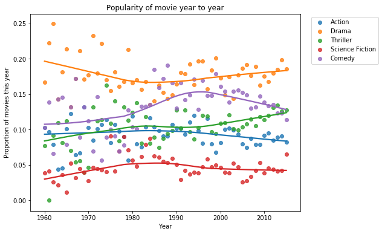

```python
fig=plt.subplots(figsize=(8,6))
g_list=['Action','Drama','Thriller','Science Fiction','Comedy']
for genre in g_list :
    sns.regplot(x=occ_df_plot['year'],y= occ_df_plot[genre],label=genre, lowess=True)

plt.legend(loc='best',bbox_to_anchor=(1.3, 1))
plt.title('Popularity of movie year to year')
plt.ylabel('Proportion of movies this year')
plt.xlabel('Year')
```

### What kinds of properties are associated with movies that have high revenues?

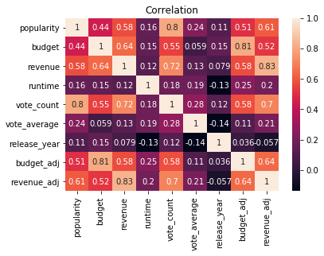

```python
# correlation map
sns.heatmap(df.corr(),annot=True)
plt.title("Correlation")
```

In this heat map, we can see that the relevant factor that are associated with high revenue could be **popularity**, **budget**, **vote counts**.

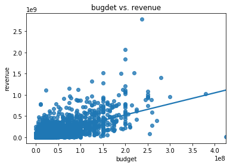

```python
#1. budget vs. revenue.
sns.regplot(x='budget',y='revenue',data=df, ci=False )
plt.title('bugdet vs. revenue')
```

In this image, we can see that there is a positive relationship between buget and revenue.

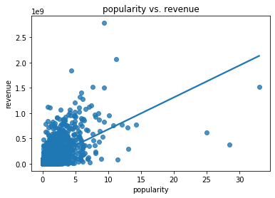

```python
#2. popularity vs. revenue.
sns.regplot(x='popularity', y='revenue', data=df, ci=False)
plt.title('popularity vs. revenue')
```

In this image, we can see that there is a positive relationship between popularity and revenue.

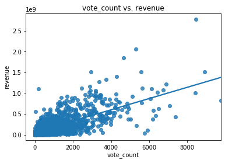

```python
#3. vote counts vs. revenue
sns.regplot(x='vote_count',y='revenue', data=df, ci=False)
plt.title('vote_count vs. revenue')
```

In this image, we can see there is a positive relationship between vote_count and revenue, but we need to consider that it's because this movie have high popularity, thus people would like to vote for it.

## Conclusions

> For Q2, we can see that budget, popularity and vote_count has positive relationship with revenue.

### Limitations

> 1. We have multiple 0 value in the revenue and budget column and we fill in the 0 with mean of other data point which may influence the analysis result.
> 2. We have a lot of missing value with production company and director, so if we could fill in the missing value and add more features in the analysis, we may get better conclusion about what factors have big impact about the revenue of movie.